# White_Wine_Exploration

Chad-Michael Renner

4/9/2017

========================================================

The wonderful world of white wines! The sugary drink that almost anybody could love. In this summary, I will be comparing some crucial factors of white wines to figure out what makes them so good. So get ready, and lets dive in

# Univariate Plots Section

```
## [1] 4898   13
```

```
##     X fixed.acidity volatile.acidity citric.acid residual.sugar chlorides
## 1   1           7.0             0.27        0.36           20.7     0.045
## 2   2           6.3             0.30        0.34            1.6     0.049
## 3   3           8.1             0.28        0.40            6.9     0.050
## 4   4           7.2             0.23        0.32            8.5     0.058
## 5   5           7.2             0.23        0.32            8.5     0.058
## 6   6           8.1             0.28        0.40            6.9     0.050
## 7   7           6.2             0.32        0.16            7.0     0.045
## 8   8           7.0             0.27        0.36           20.7     0.045
## 9   9           6.3             0.30        0.34            1.6     0.049
## 10 10           8.1             0.22        0.43            1.5     0.044
##    free.sulfur.dioxide total.sulfur.dioxide density   pH sulphates alcohol
## 1                   45                  170  1.0010 3.00      0.45     8.8
## 2                   14                  132  0.9940 3.30      0.49     9.5
## 3                   30                   97  0.9951 3.26      0.44    10.1
```

[output cut: 18 more lines]

```
##        X        fixed.acidity    volatile.acidity  citric.acid
##  Min.   :   1   Min.   : 3.800   Min.   :0.0800   Min.   :0.0000
##  1st Qu.:1225   1st Qu.: 6.300   1st Qu.:0.2100   1st Qu.:0.2700
##  Median :2450   Median : 6.800   Median :0.2600   Median :0.3200
##  Mean   :2450   Mean   : 6.855   Mean   :0.2782   Mean   :0.3342
##  3rd Qu.:3674   3rd Qu.: 7.300   3rd Qu.:0.3200   3rd Qu.:0.3900
##  Max.   :4898   Max.   :14.200   Max.   :1.1000   Max.   :1.6600
##  residual.sugar     chlorides       free.sulfur.dioxide
##  Min.   : 0.600   Min.   :0.00900   Min.   :  2.00
##  1st Qu.: 1.700   1st Qu.:0.03600   1st Qu.: 23.00
##  Median : 5.200   Median :0.04300   Median : 34.00
##  Mean   : 6.391   Mean   :0.04577   Mean   : 35.31
##  3rd Qu.: 9.900   3rd Qu.:0.05000   3rd Qu.: 46.00
##  Max.   :65.800   Max.   :0.34600   Max.   :289.00
##  total.sulfur.dioxide    density             pH          sulphates
##  Min.   :  9.0        Min.   :0.9871   Min.   :2.720   Min.   :0.2200
##  1st Qu.:108.0        1st Qu.:0.9917   1st Qu.:3.090   1st Qu.:0.4100
##  Median :134.0        Median :0.9937   Median :3.180   Median :0.4700
##  Mean   :138.4        Mean   :0.9940   Mean   :3.188   Mean   :0.4898
##  3rd Qu.:167.0        3rd Qu.:0.9961   3rd Qu.:3.280   3rd Qu.:0.5500
##  Max.   :440.0        Max.   :1.0390   Max.   :3.820   Max.   :1.0800
##     alcohol         quality
##  Min.   : 8.00   Min.   :3.000
##  1st Qu.: 9.50   1st Qu.:5.000
##  Median :10.40   Median :6.000
##  Mean   :10.51   Mean   :5.878
##  3rd Qu.:11.40   3rd Qu.:6.000
##  Max.   :14.20   Max.   :9.000
```

Above, you will see the dimensions, first 10 lines, and a summary of each column. Looking at the above, you will notice that column X goes from 1 to 4898, which is how many observations we have. Because of this, I made the X column a factor, to label each individual wine.

With this data layed out, I am able to see the data and sections but unable to really visualize any information. Now I am going to move on to some univariate plots to display the data so I can visualize and analyze further.

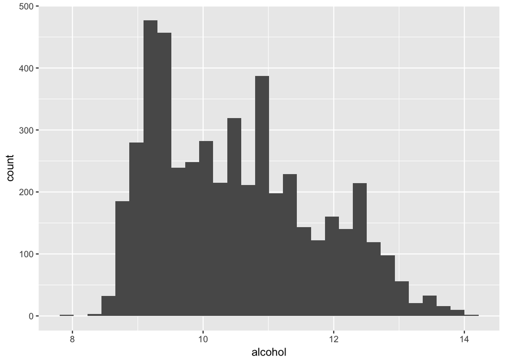

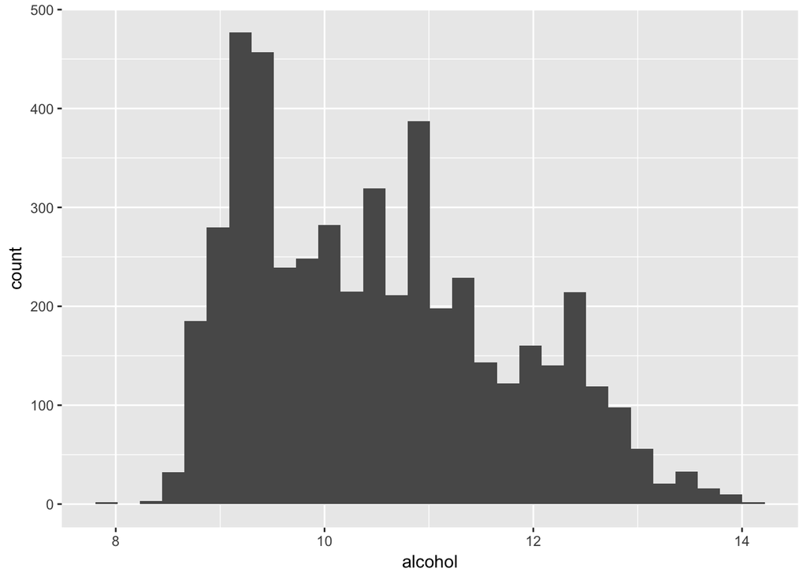

```
## <ScaleContinuousPosition>
##  Range:
##  Limits:    0 --    1
```

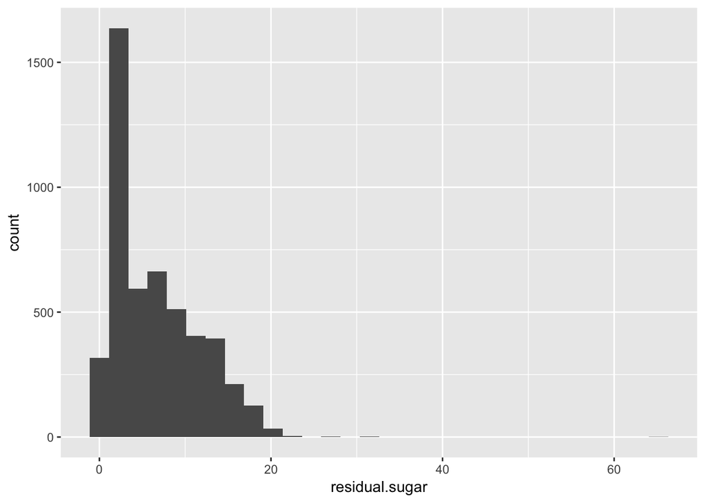

Summary of Residual Sugar

```
##    Min. 1st Qu.  Median    Mean 3rd Qu.    Max.
##   0.600   1.700   5.200   6.391   9.900  65.800
```

Summary of Residual Sugar Log10

```
##    Min. 1st Qu.  Median    Mean 3rd Qu.    Max.
## -0.2218  0.2304  0.7160  0.6432  0.9956  1.8180
```

```
##    Min. 1st Qu.  Median    Mean 3rd Qu.    Max.
##  0.7746  1.3040  2.2800  2.3200  3.1460  8.1120
```

### Transforming Data

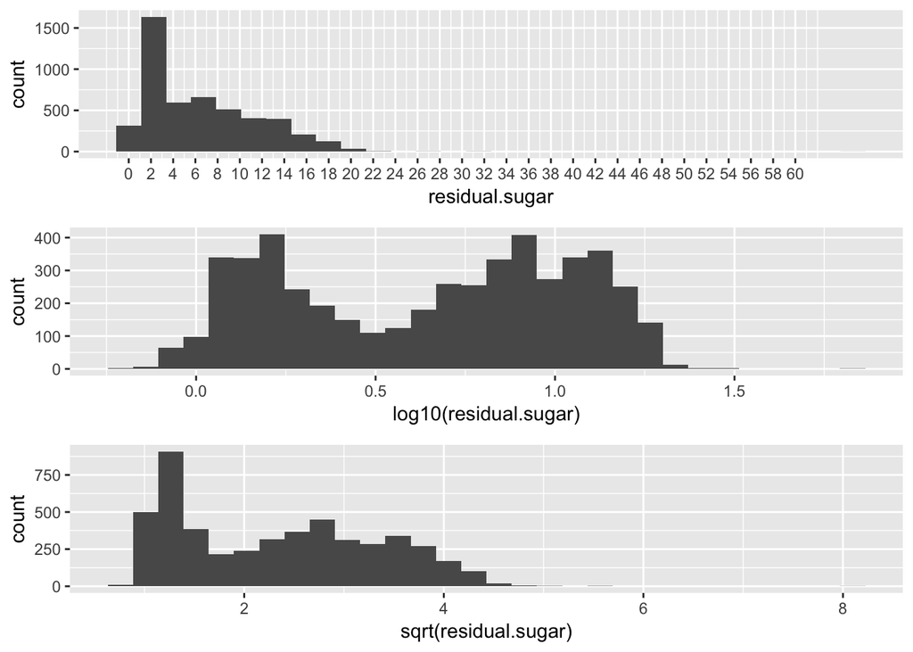

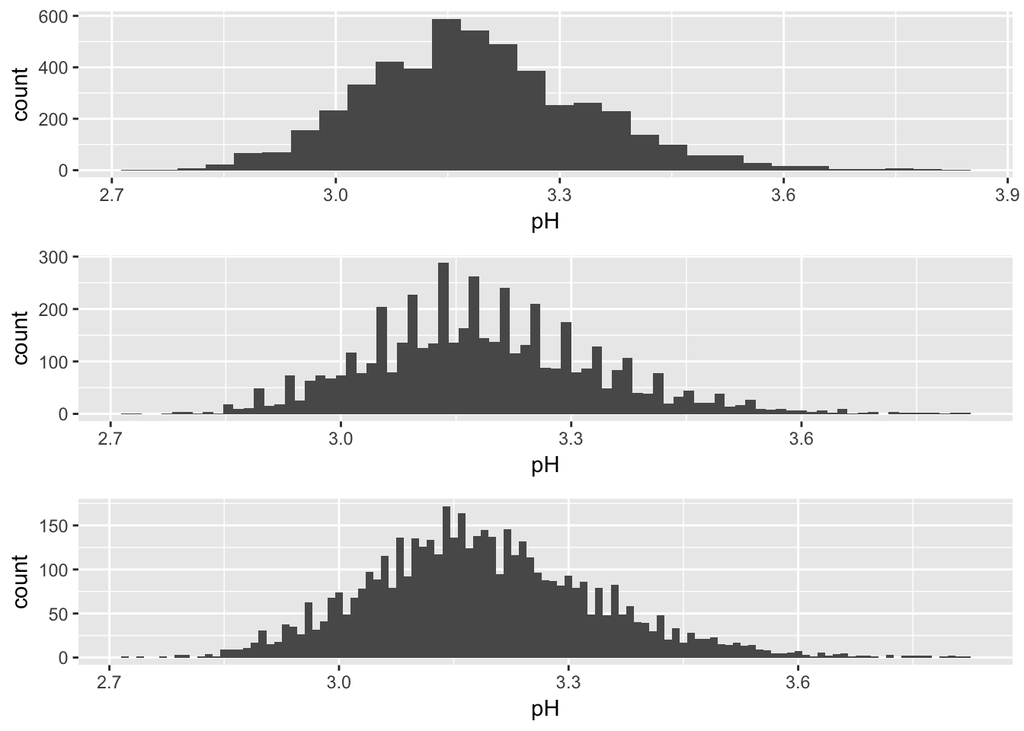

# Univariate Analysis

### What is/are the main feature(s) of interest?

The main feature of this dataset is the quality of the wine. All of the data revolves around the quality, with certain areas of interest such as the pH, residual sugar, and the acidity.

# Bivariate Plots Section

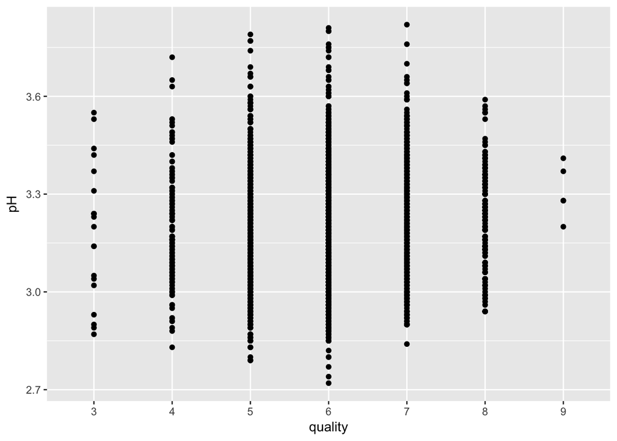

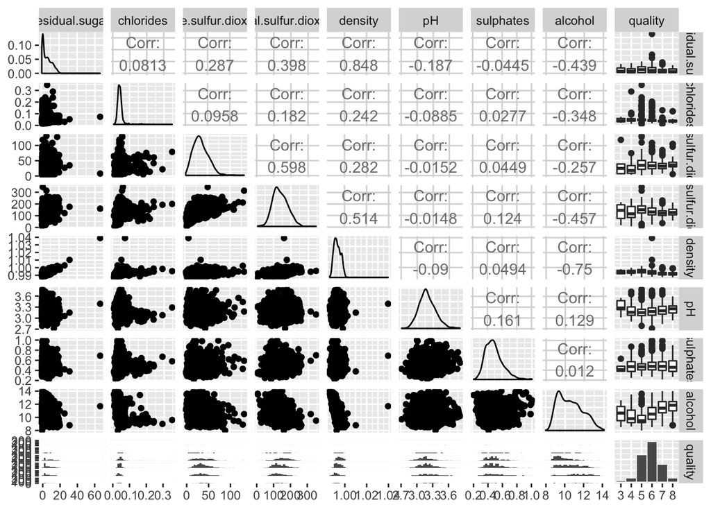

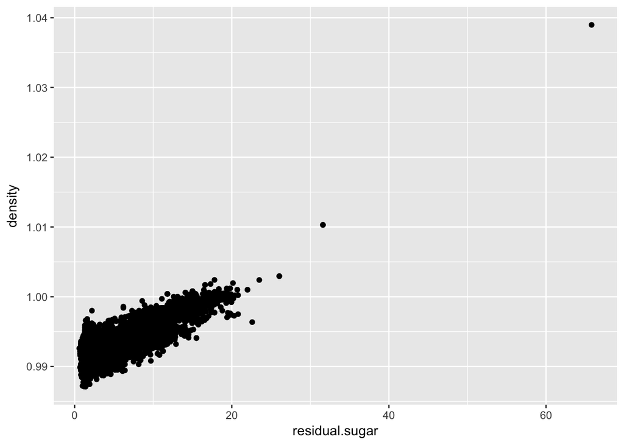

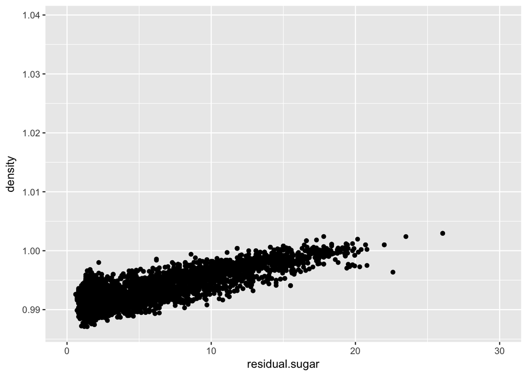

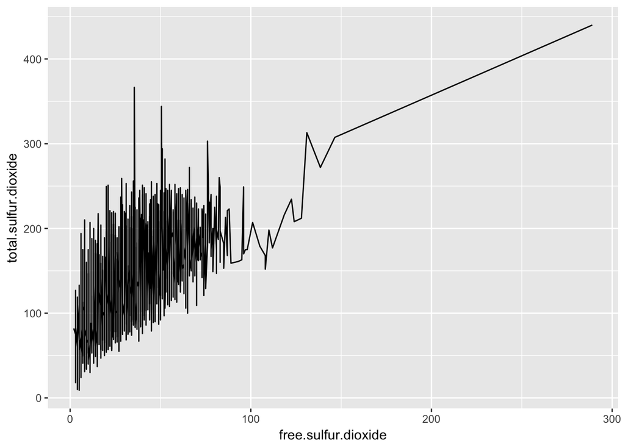

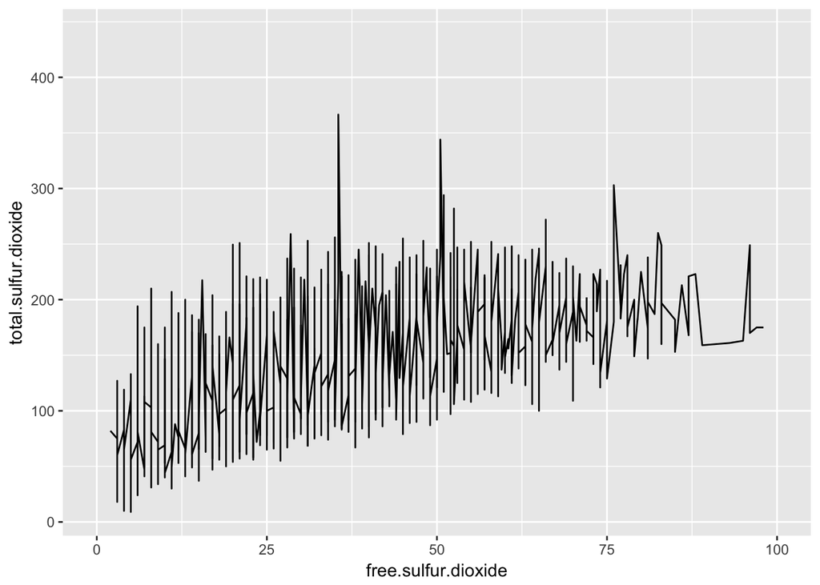

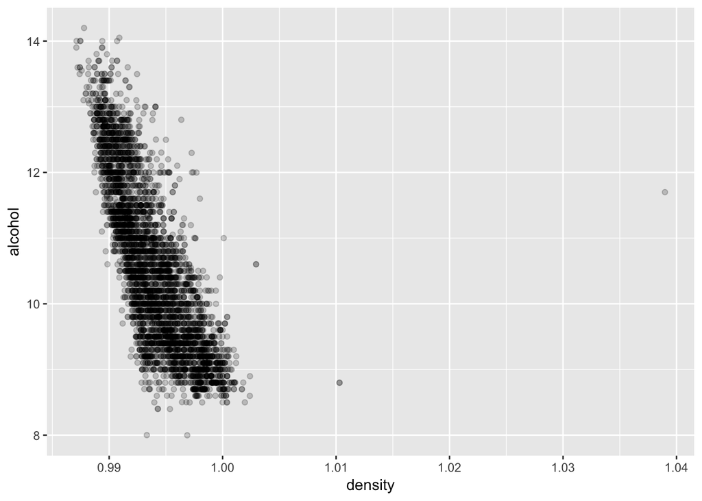

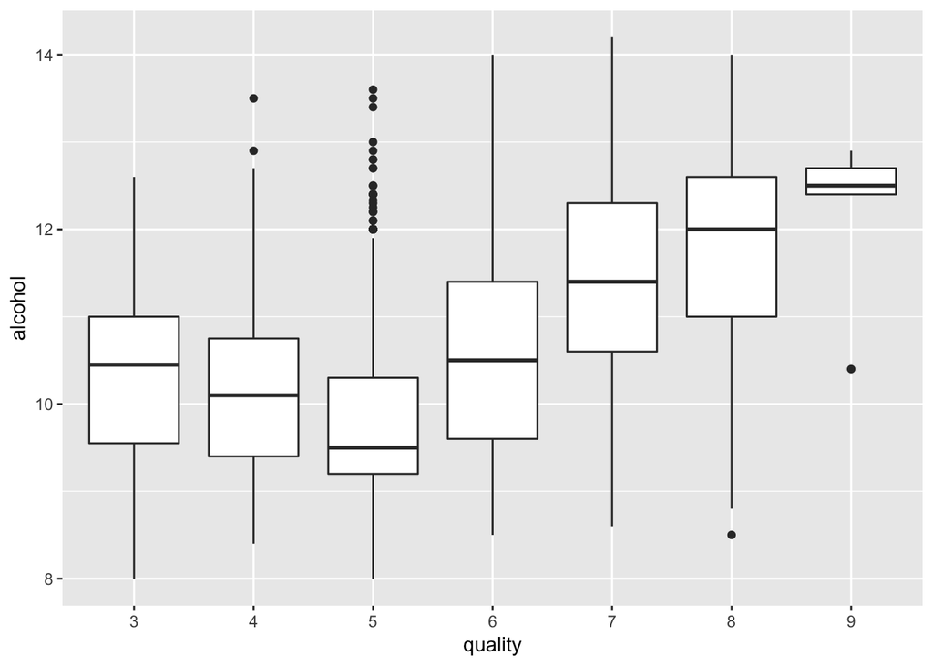

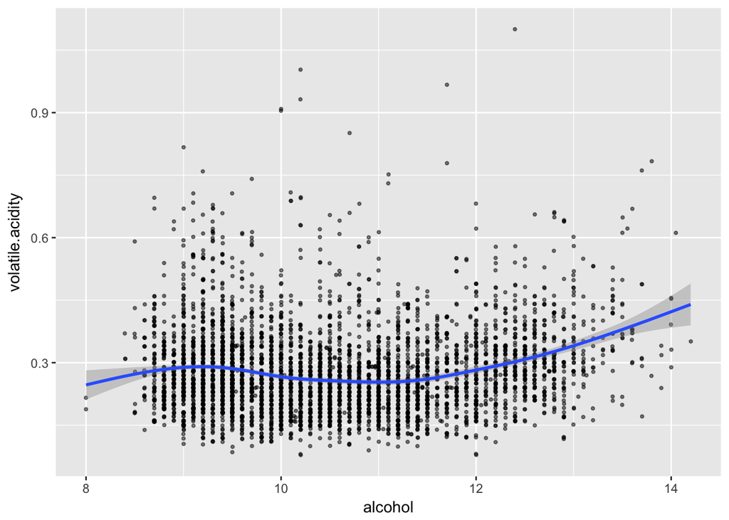

```
## (7.99,9.24] (9.24,10.5] (10.5,11.7]   (11.7,13]   (13,14.2]
##         845        1730        1390         795         138
```

```
##
##  Descriptive statistics by group
## group: (7.99,9.24]
##    vars   n mean  sd median trimmed  mad min  max range skew kurtosis se
## X1    1 845 0.28 0.1   0.27    0.27 0.07 0.1 0.82  0.71 1.47      3.2  0
## --------------------------------------------------------
## group: (9.24,10.5]
##    vars    n mean  sd median trimmed  mad  min max range skew kurtosis se
## X1    1 1730 0.28 0.1   0.26    0.27 0.09 0.08   1  0.92  1.7     5.87  0
## --------------------------------------------------------
## group: (10.5,11.7]
##    vars    n mean   sd median trimmed  mad  min  max range skew kurtosis
## X1    1 1390 0.26 0.09   0.24    0.25 0.07 0.09 0.96  0.88 1.79     6.76
##    se
## X1  0
## --------------------------------------------------------
## group: (11.7,13]
##    vars   n mean  sd median trimmed  mad  min max range skew kurtosis se
## X1    1 795  0.3 0.1   0.29    0.29 0.07 0.08 1.1  1.02 1.45     6.37  0
## --------------------------------------------------------
## group: (13,14.2]
##    vars   n mean   sd median trimmed mad  min  max range skew kurtosis
## X1    1 138 0.37 0.12   0.35    0.36 0.1 0.15 0.78  0.64 0.87     1.18
##      se
## X1 0.01
```

# Bivariate Analysis

### Relationships:

There are a lot of interesting relationships in the data, such as alcohol vs quality. It is very interesting that the quality of the wine actually increases as the amount of alcohol increases. There are also interesting relationships between the residual sugar vs. density and the relationship of valatile acidity compared to alcohol.

Lets dig deeper into these relationships and explore some multvariate analysis to see where this takes us in the wine exploration

# Multivariate Plots Section

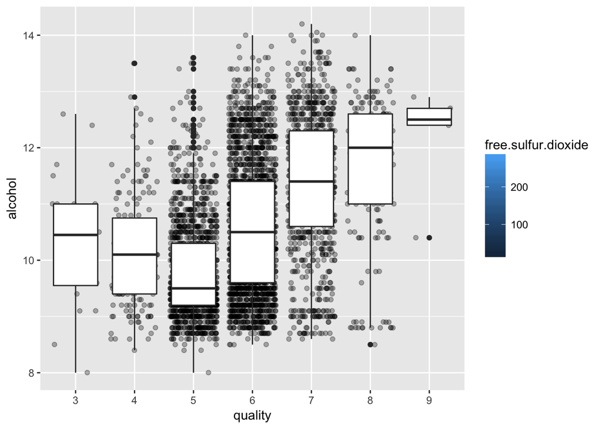

```
## (7.99,10.1] (10.1,12.1] (12.1,14.2]
##        2086        2154         658
```

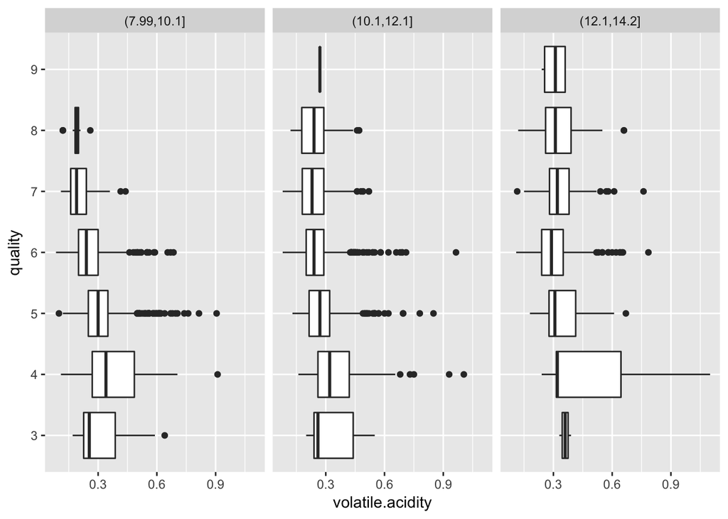

# Final Plots and Summary

### Plot One

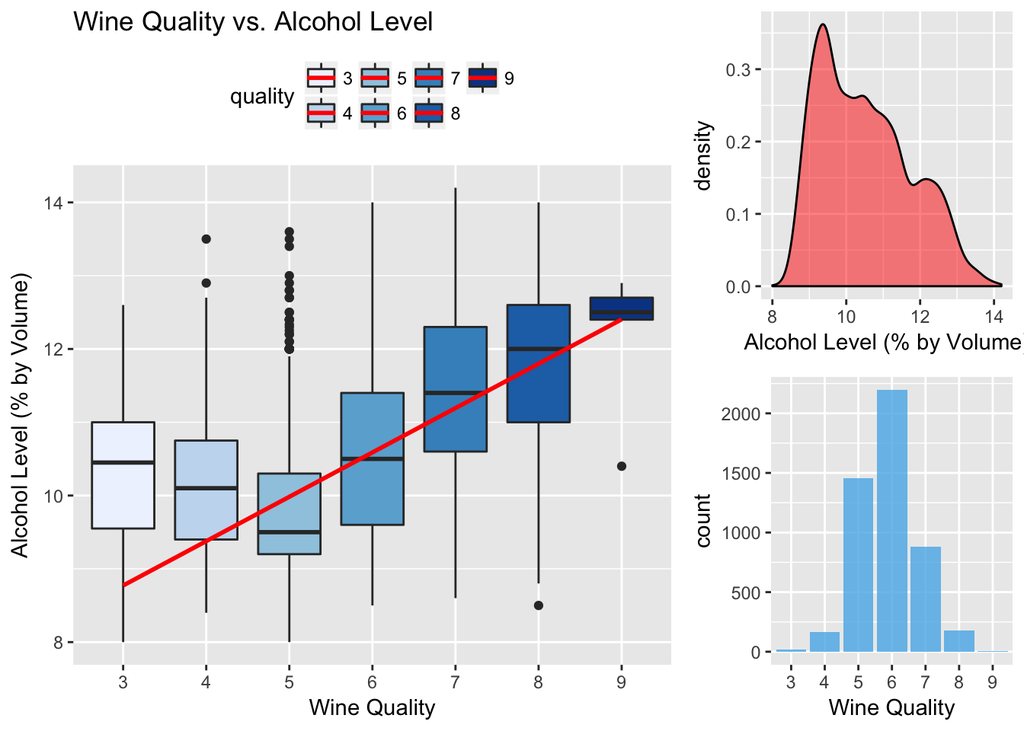

```
##
##  Descriptive statistics by group
## group: 3
##    vars  n  mean   sd median trimmed  mad min  max range skew kurtosis
## X1    1 20 10.35 1.22  10.45   10.34 1.19   8 12.6   4.6 0.02    -0.83
##      se
## X1 0.27
## --------------------------------------------------------
## group: 4
##    vars   n  mean sd median trimmed  mad min  max range skew kurtosis   se
## X1    1 163 10.15  1   10.1   10.08 1.04 8.4 13.5   5.1  0.7     0.15 0.08
## --------------------------------------------------------
## group: 5
##    vars    n mean   sd median trimmed  mad min  max range skew kurtosis
## X1    1 1457 9.81 0.85    9.5    9.71 0.74   8 13.6   5.6 1.08     1.07
##      se
## X1 0.02
## --------------------------------------------------------
## group: 6
##    vars    n  mean   sd median trimmed  mad min max range skew kurtosis
## X1    1 2198 10.58 1.15   10.5   10.52 1.33 8.5  14   5.5  0.4    -0.72
##      se
## X1 0.02
## --------------------------------------------------------
## group: 7
##    vars   n  mean   sd median trimmed  mad min  max range skew kurtosis
## X1    1 880 11.37 1.25   11.4   11.42 1.33 8.6 14.2   5.6 -0.3    -0.56
##      se
## X1 0.04
## --------------------------------------------------------
## group: 8
##    vars   n  mean   sd median trimmed  mad min max range  skew kurtosis
## X1    1 175 11.64 1.28     12   11.78 1.19 8.5  14   5.5 -0.89     0.01
##     se
## X1 0.1
## --------------------------------------------------------
## group: 9
##    vars n  mean   sd median trimmed mad  min  max range  skew kurtosis
## X1    1 5 12.18 1.01   12.5   12.18 0.3 10.4 12.9   2.5 -0.98    -1.03
##      se
## X1 0.45
```

### Plot Two

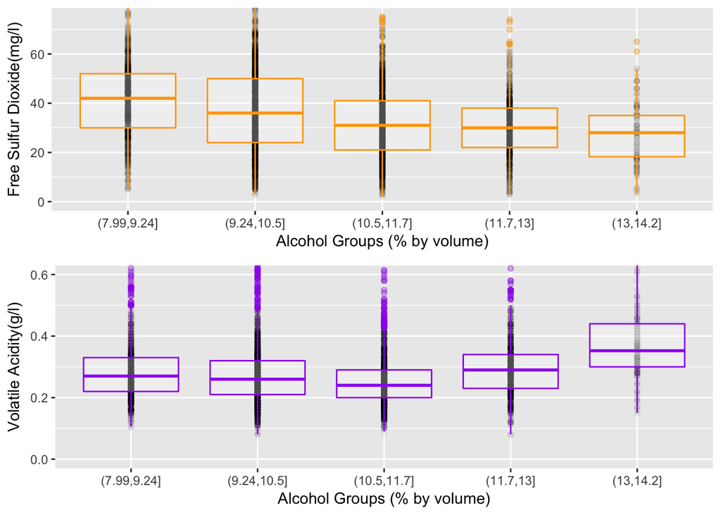

```
##
##  Descriptive statistics by group
## group: (7.99,9.24]
##    vars   n  mean    sd median trimmed   mad min max range skew kurtosis
## X1    1 845 41.51 15.79     42   41.34 16.31   5 128   123 0.32     0.93
##      se
## X1 0.54
## --------------------------------------------------------
## group: (9.24,10.5]
##    vars    n  mean    sd median trimmed   mad min   max range skew
## X1    1 1730 37.54 18.09     36   36.72 19.27   3 138.5 135.5  0.6
##    kurtosis   se
## X1     0.78 0.44
## --------------------------------------------------------
## group: (10.5,11.7]
##    vars    n  mean    sd median trimmed   mad min max range skew kurtosis
## X1    1 1390 32.28 17.19     31   31.09 14.83   2 289   287 3.34    38.23
##      se
## X1 0.46
## --------------------------------------------------------
## group: (11.7,13]
##    vars   n  mean    sd median trimmed   mad min max range skew kurtosis
## X1    1 795 30.44 12.74     30   29.96 11.86   3  96    93 0.77     2.48
##      se
## X1 0.45
## --------------------------------------------------------
## group: (13,14.2]
##    vars   n  mean    sd median trimmed   mad min max range skew kurtosis
## X1    1 138 27.88 12.14     28   27.35 13.34   3  65    62  0.4    -0.07
##      se
## X1 1.03
```

```
##
##  Descriptive statistics by group
## group: (7.99,9.24]
##    vars   n mean  sd median trimmed  mad min  max range skew kurtosis se
## X1    1 845 0.28 0.1   0.27    0.27 0.07 0.1 0.82  0.71 1.47      3.2  0
## --------------------------------------------------------
## group: (9.24,10.5]
##    vars    n mean  sd median trimmed  mad  min max range skew kurtosis se
## X1    1 1730 0.28 0.1   0.26    0.27 0.09 0.08   1  0.92  1.7     5.87  0
## --------------------------------------------------------
## group: (10.5,11.7]
##    vars    n mean   sd median trimmed  mad  min  max range skew kurtosis
## X1    1 1390 0.26 0.09   0.24    0.25 0.07 0.09 0.96  0.88 1.79     6.76
##    se
## X1  0
## --------------------------------------------------------
## group: (11.7,13]
##    vars   n mean  sd median trimmed  mad  min max range skew kurtosis se
## X1    1 795  0.3 0.1   0.29    0.29 0.07 0.08 1.1  1.02 1.45     6.37  0
## --------------------------------------------------------
## group: (13,14.2]
##    vars   n mean   sd median trimmed mad  min  max range skew kurtosis
## X1    1 138 0.37 0.12   0.35    0.36 0.1 0.15 0.78  0.64 0.87     1.18
##      se
## X1 0.01
```

### Description Two

The combined two charts below plot alcohol against free sulfur dioxide and volatile acidity. The higher the alcohol level is, the less the free sulfur dioxide will be. For example, the median free sulfur dioxide amount among 13-14.2% alcohol group is only 28 mg/l, much less than 42 mg/l among 7.99-9.24% alcohol group. The relatinship between acidity and alcohol becomes more clear among higher alcohol groups. For instance, the median volatile acidity amount among 13-14.2% alcohol group is 0.35 g/l as compared to 0.24 g/l among 10.5-11.7% alcohol group.

### Plot Three

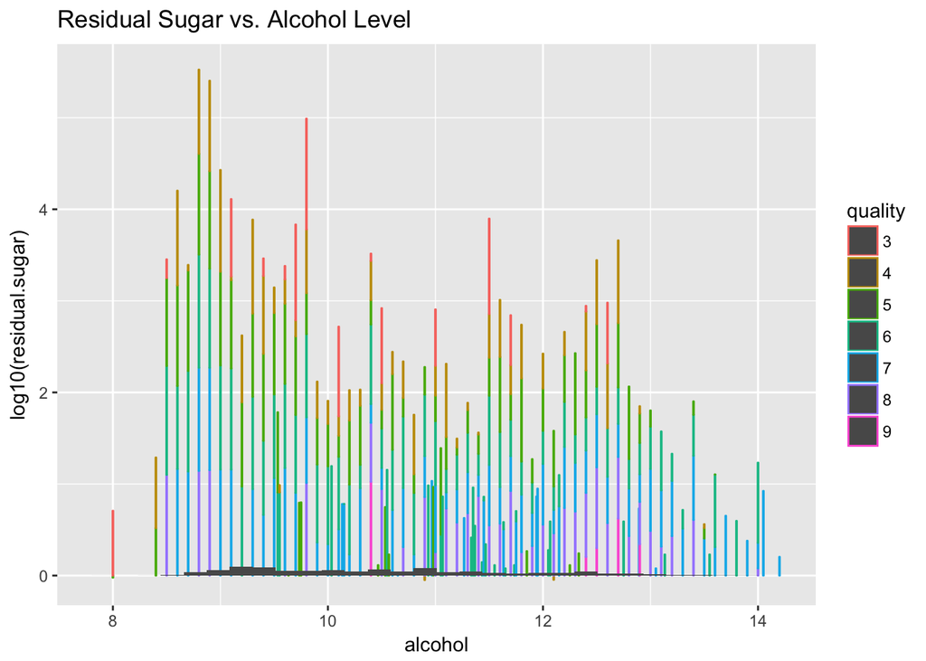

### Description Three

# Reflection

This white wine dataset is the most tidy one I’ve ever used. However, I was frustrated in the beginning because except alcohol, almost all other input variables don’t have a strong relationship with wine quality. Reading correlation matrix is not enough. When conditioning on other relevant variables, the relationships between the physicochemical properties and quality became clear. Also, all input variables are continous variables which limited the type of graphs I could make. One solution I made was to recode to categorical variables.

The other problem I had is my knowledge about the physicochemicals and how they interacted were limited before starting this project. I had to resort to additional readings to brush up my wine knowledge.

This dataset is pretty limited with 13 input variables (technically 12 can be used for analysis because one of them is ID variable), it will be great if other variables such as grape type and wine age can be included for further investigation.